# 1.

Please discuss the tension between bias and variance during developing a machine learning model. What is the difference between them and what is the trade-off? How would you classify decision trees and linear regression regarding their level of bias.

## Answer

- High Bias suggest training data have less affects on target data so its make less assumptions about target data.
- High Variance suggest training data is very influential on target data so its make too many assumptions about target data.
- We can divide prediction error tree which are
  - Bias Error
  - Variance Error
  - Irreducible Error

We can not reduce irreducible error. Our goal is reduce total of Bias Error and Variance Error.

- For try to minimize Bias Error + Variance Error. We can use;
  - Cross Validation
  - Early Stopping
  - Pruning
  - Regularization

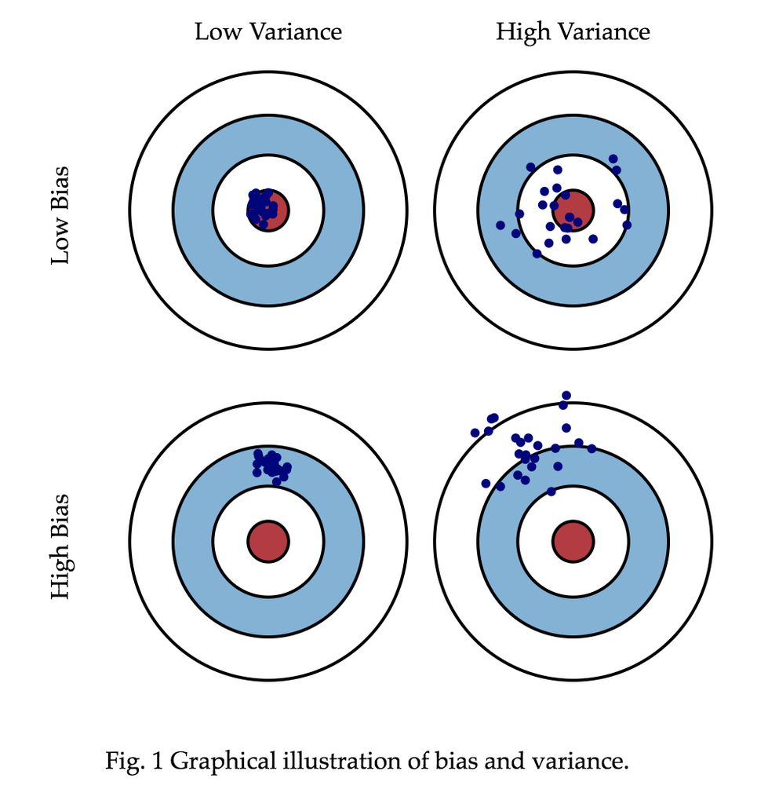

```python
from IPython.display import Image
from IPython.core.display import HTML
PATH = "/Users/yetkineser/Desktop/"
Image(filename = PATH + "biasvariance.png", width=700, height=500)
```

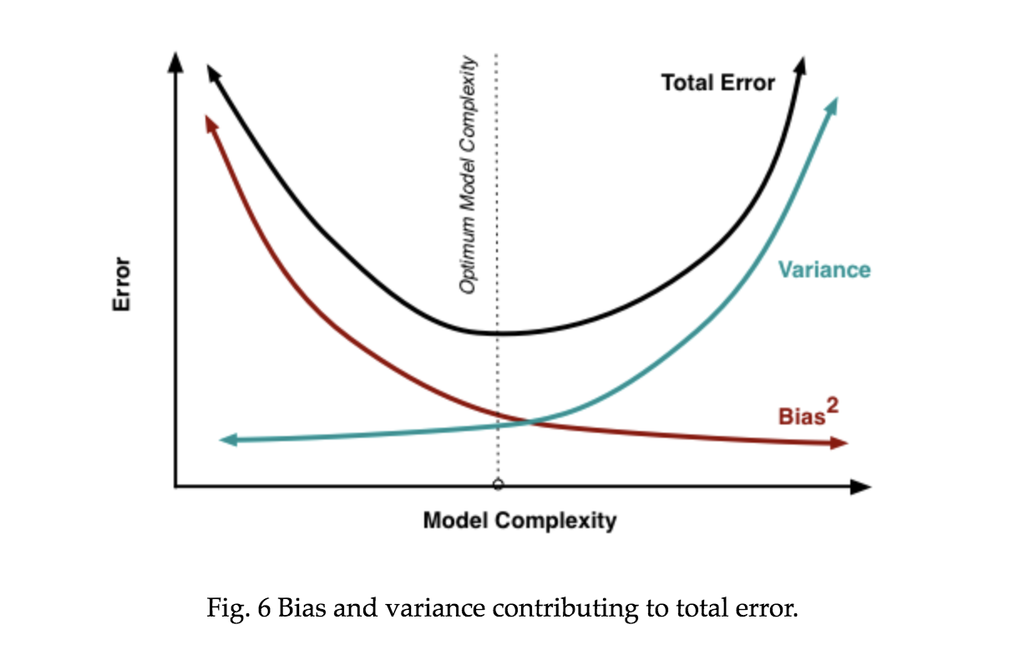

```python
Image(filename = PATH + "biasvariance2.png", width=700, height=500)
```

**References**

- https://elitedatascience.com/bias-variance-tradeoff
- http://scott.fortmann-roe.com/docs/BiasVariance.html
- https://machinelearningmastery.com/gentle-introduction-to-the-bias-variance-trade-off-in-machine-learning/

# 2.

You are expected to provide the descriptive information about the iris dataset. How many classes, cases and potential features are there? Please find the average values for each class regarding different features. Thus, we will have a rough idea about the potential differences about the classes. A manually made table will also be sufficient but you can also code it.

```python
import numpy as np
import pandas as pd
import matplotlib.pyplot as plt
from sklearn import datasets
from sklearn import svm
from sklearn.utils import shuffle

%matplotlib inline
iris = datasets.load_iris()


# np.c_ is the numpy concatenate function
# which is used to concat iris['data'] and iris['target'] arrays
# for pandas column argument: concat iris['feature_names'] list
# and string list (in this case one string); you can make this anything you'd like..
# the original dataset would probably call this ['Species']
iris_df = pd.DataFrame(data= np.c_[iris['data'], iris['target']],
                     columns= iris['feature_names'] + ['target'])

#iris_df = pd.DataFrame(data= np.c_[iris['data'], iris['target_names'][iris['target']]],
#                     columns= iris['feature_names'] + ['target'])

iris_df = shuffle(iris_df) # important to shuffle data

iris_df = iris_df
iris_df[['target']] = iris_df_2[['target']].astype('object')
```

```python
iris_df.head(20).T
```

|  | 94 | 85 | 95 | 125 | 70 | 135 | 69 | 34 | 49 | 87 | 90 | 144 | 98 | 129 | 103 | 5 | 54 | 121 | 39 | 12 |
| --- | --- | --- | --- | --- | --- | --- | --- | --- | --- | --- | --- | --- | --- | --- | --- | --- | --- | --- | --- | --- |
| sepal length (cm) | 5.6 | 6 | 5.7 | 7.2 | 5.9 | 7.7 | 5.6 | 4.9 | 5 | 6.3 | 5.5 | 6.7 | 5.1 | 7.2 | 6.3 | 5.4 | 6.5 | 5.6 | 5.1 | 4.8 |
| sepal width (cm) | 2.7 | 3.4 | 3 | 3.2 | 3.2 | 3 | 2.5 | 3.1 | 3.3 | 2.3 | 2.6 | 3.3 | 2.5 | 3 | 2.9 | 3.9 | 2.8 | 2.8 | 3.4 | 3 |
| petal length (cm) | 4.2 | 4.5 | 4.2 | 6 | 4.8 | 6.1 | 3.9 | 1.5 | 1.4 | 4.4 | 4.4 | 5.7 | 3 | 5.8 | 5.6 | 1.7 | 4.6 | 4.9 | 1.5 | 1.4 |
| petal width (cm) | 1.3 | 1.6 | 1.2 | 1.8 | 1.8 | 2.3 | 1.1 | 0.1 | 0.2 | 1.3 | 1.2 | 2.5 | 1.1 | 1.6 | 1.8 | 0.4 | 1.5 | 2 | 0.2 | 0.1 |
| target | 1 | 1 | 1 | 2 | 1 | 2 | 1 | 0 | 0 | 1 | 1 | 2 | 1 | 2 | 2 | 0 | 1 | 2 | 0 | 0 |

```python
# Show rows and columns number
iris_df.shape
```

```
(150, 5)
```

```python
iris_df.info()
```

```
<class 'pandas.core.frame.DataFrame'>
Int64Index: 150 entries, 94 to 25
Data columns (total 5 columns):
sepal length (cm)    150 non-null float64
sepal width (cm)     150 non-null float64
petal length (cm)    150 non-null float64
petal width (cm)     150 non-null float64
target               150 non-null object
dtypes: float64(4), object(1)
memory usage: 7.0+ KB
```

```python
# iris_df['target'] = str(round(iris_df['target']))
```

```python
iris_df.groupby('target').describe().T
```

|  | target | 0.0 | 1.0 | 2.0 |
| --- | --- | --- | --- | --- |
| petal length (cm) | count | 50.000000 | 50.000000 | 50.000000 |
|  | mean | 1.464000 | 4.260000 | 5.552000 |
|  | std | 0.173511 | 0.469911 | 0.551895 |
|  | min | 1.000000 | 3.000000 | 4.500000 |
|  | 25% | 1.400000 | 4.000000 | 5.100000 |
|  | 50% | 1.500000 | 4.350000 | 5.550000 |
|  | 75% | 1.575000 | 4.600000 | 5.875000 |
|  | max | 1.900000 | 5.100000 | 6.900000 |
| petal width (cm) | count | 50.000000 | 50.000000 | 50.000000 |
|  | mean | 0.244000 | 1.326000 | 2.026000 |
|  | std | 0.107210 | 0.197753 | 0.274650 |
|  | min | 0.100000 | 1.000000 | 1.400000 |
|  | 25% | 0.200000 | 1.200000 | 1.800000 |
|  | 50% | 0.200000 | 1.300000 | 2.000000 |
|  | 75% | 0.300000 | 1.500000 | 2.300000 |
|  | max | 0.600000 | 1.800000 | 2.500000 |
| sepal length (cm) | count | 50.000000 | 50.000000 | 50.000000 |
|  | mean | 5.006000 | 5.936000 | 6.588000 |
|  | std | 0.352490 | 0.516171 | 0.635880 |
|  | min | 4.300000 | 4.900000 | 4.900000 |
|  | 25% | 4.800000 | 5.600000 | 6.225000 |
|  | 50% | 5.000000 | 5.900000 | 6.500000 |
|  | 75% | 5.200000 | 6.300000 | 6.900000 |
|  | max | 5.800000 | 7.000000 | 7.900000 |
| sepal width (cm) | count | 50.000000 | 50.000000 | 50.000000 |
|  | mean | 3.418000 | 2.770000 | 2.974000 |
|  | std | 0.381024 | 0.313798 | 0.322497 |
|  | min | 2.300000 | 2.000000 | 2.200000 |
|  | 25% | 3.125000 | 2.525000 | 2.800000 |
|  | 50% | 3.400000 | 2.800000 | 3.000000 |
|  | 75% | 3.675000 | 3.000000 | 3.175000 |
|  | max | 4.400000 | 3.400000 | 3.800000 |

# 3.

Please run the code for iris dataset for linear regression. You should select one feature as the target the rest as the predictors. Please determine the best combination among the others. Please do not forget to provide test-train comparison.

**Note:** I choose *petal width* for my target variable.

```python
from sklearn import linear_model
from sklearn.model_selection import train_test_split
```

```python
X_train, X_test, y_train, y_test = train_test_split(
...     iris_df[["target","sepal length (cm)","sepal width (cm)","petal length (cm)"]], iris_df["petal width (cm)"], test_size=0.3, random_state=0)
```

```python
reg = linear_model.LinearRegression()
reg.fit(X_train, y_train)
```

```
LinearRegression(copy_X=True, fit_intercept=True, n_jobs=1, normalize=False)
```

```python
reg.coef_
```

```
array([ 0.33081075, -0.13767181,  0.19460663,  0.34410049])
```

```python
print("Accuracy on training set: {:.3f}".format(reg.score(X_train,y_train)))
print("Accuracy on test set: {:.3f}".format(reg.score(X_test,y_test)))
```

```
Accuracy on training set: 0.946
Accuracy on test set: 0.962
```

- We can also use cross validation for train test split.
- I thought cross validation is better to decide which model we should use.

```python
from sklearn.model_selection import cross_val_score
```

```python
iris_feature = iris_df[["target","sepal length (cm)","sepal width (cm)","petal length (cm)"]]
iris_label = iris_df["petal width (cm)"]
scores = cross_val_score(reg, iris_feature, iris_label, cv=5)
```

```python
scores
```

```
array([ 0.93459129,  0.96204248,  0.96026282,  0.93160719,  0.956895  ])
```

```python
np.mean(scores)
```

```
0.94907975651543663
```

# 4.

Please apply the same procedure with Ridge and Lasso methods to the best dual combination in the question above with a slight mention about L1 and L2 regularization. Please briefly explain what these methods are sensitive to.

### for cross validation

```python
from sklearn.linear_model import Ridge
Ridge()
```

```
Ridge(alpha=1.0, copy_X=True, fit_intercept=True, max_iter=None,
   normalize=False, random_state=None, solver='auto', tol=0.001)
```

```python
ridge = Ridge()
scores_ridge = cross_val_score(ridge, iris_feature, iris_label, cv=5)
print(scores_ridge)
np.mean(scores_ridge)
```

```
[ 0.93493388  0.9614377   0.96092697  0.93063792  0.95753713]
```

```
0.94909471897462594
```

```python
ridge10 = Ridge(alpha=10)
scores_ridge10 = cross_val_score(ridge10, iris_feature, iris_label, cv=5)
print(scores_ridge10)
np.mean(scores_ridge10)
```

```
[ 0.93134878  0.95339218  0.95606023  0.92143706  0.9545593 ]
```

```
0.94335950977593686
```

```python
ridge01 = Ridge(alpha=0.1)
scores_ridge01 = cross_val_score(ridge01, iris_feature, iris_label, cv=5)
print(scores_ridge01)
np.mean(scores_ridge01)
```

```
[ 0.9346483   0.96199651  0.96037315  0.93152026  0.95698748]
```

```
0.94910513920124639
```

```python
ridge2 = Ridge(alpha=2)
scores_ridge2 = cross_val_score(ridge2, iris_feature, iris_label, cv=5)
print(scores_ridge2)
np.mean(scores_ridge2)
```

```
[ 0.93490872  0.96061824  0.96092873  0.92953836  0.95772188]
```

```
0.94874318648424993
```

```python
from sklearn.linear_model import Lasso
Lasso()
```

```
Lasso(alpha=1.0, copy_X=True, fit_intercept=True, max_iter=1000,
   normalize=False, positive=False, precompute=False, random_state=None,
   selection='cyclic', tol=0.0001, warm_start=False)
```

```python
lasso = Lasso()
scores_lasso = cross_val_score(lasso, iris_feature, iris_label, cv=5)
print(scores_lasso)
np.mean(scores_lasso)
```

```
[ 0.39696813  0.35632155  0.32002968  0.31553576  0.3507727 ]
```

```
0.34792556278536324
```

```python
lasso10 = Lasso(alpha=10)
scores_lasso10 = cross_val_score(lasso10, iris_feature, iris_label, cv=5)
print(scores_lasso10)
np.mean(scores_lasso10)
```

```
[-0.01463868 -0.03321958 -0.06679125 -0.00883788 -0.01843022]
```

```
-0.028383521908578579
```

```python
lasso0001 = Lasso(alpha=0.001)
scores_lasso0001 = cross_val_score(lasso0001, iris_feature, iris_label, cv=5)
print(scores_lasso0001)
np.mean(scores_lasso0001)
```

```
[ 0.93419969  0.9614282   0.96089235  0.93105963  0.95751017]
```

```
0.94901800875412934
```

### for normal train test split

```python
reg = linear_model.LinearRegression()
reg.fit(X_train, y_train)
print("Accuracy on training set: {:.3f}".format(reg.score(X_train,y_train)))
print("Accuracy on test set: {:.3f}".format(reg.score(X_test,y_test)))
```

```
Accuracy on training set: 0.946
Accuracy on test set: 0.962
```

```python
ridge = Ridge().fit(X_train, y_train)
print("Accuracy on training set: {:.3f}".format(ridge.score(X_train,y_train)))
print("Accuracy on test set: {:.3f}".format(ridge.score(X_test,y_test)))
```

```
Accuracy on training set: 0.946
Accuracy on test set: 0.962
```

```python
ridge10 = Ridge(alpha=10).fit(X_train, y_train)
print("Accuracy on training set: {:.3f}".format(ridge10.score(X_train,y_train)))
print("Accuracy on test set: {:.3f}".format(ridge10.score(X_test,y_test)))
```

```
Accuracy on training set: 0.939
Accuracy on test set: 0.953
```

```python
ridge01 = Ridge(alpha=0.1).fit(X_train, y_train)
print("Accuracy on training set: {:.3f}".format(ridge01.score(X_train,y_train)))
print("Accuracy on test set: {:.3f}".format(ridge01.score(X_test,y_test)))
```

```
Accuracy on training set: 0.946
Accuracy on test set: 0.962
```

```python
ridge2 = Ridge(alpha=2).fit(X_train, y_train)
print("Accuracy on training set: {:.3f}".format(ridge2.score(X_train,y_train)))
print("Accuracy on test set: {:.3f}".format(ridge2.score(X_test,y_test)))
```

```
Accuracy on training set: 0.946
Accuracy on test set: 0.961
```

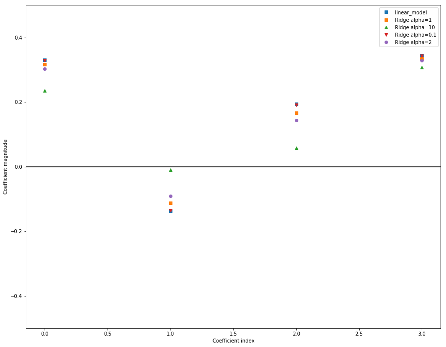

```python
plt.figure(figsize=(15,12))
plt.plot(reg.coef_, 's', label="linear_model")
plt.plot(ridge.coef_, 's', label="Ridge alpha=1")
plt.plot(ridge10.coef_, '^', label="Ridge alpha=10")
plt.plot(ridge01.coef_, 'v', label="Ridge alpha=0.1")
plt.plot(ridge2.coef_, 'o', label="Ridge alpha=2")

plt.xlabel("Coefficient index")
plt.ylabel("Coefficient magnitude")
xlims = plt.xlim()
plt.hlines(0, xlims[0], xlims[1])
plt.xlim(xlims)
plt.ylim(-0.5, 0.5)
plt.legend()
```

```python
lasso = Lasso().fit(X_train, y_train)
print("Accuracy on training set: {:.3f}".format(lasso.score(X_train,y_train)))
print("Accuracy on test set: {:.3f}".format(lasso.score(X_test,y_test)))
```

```
Accuracy on training set: 0.364
Accuracy on test set: 0.340
```

```python
lasso10 = Lasso(alpha=10).fit(X_train, y_train)
print("Accuracy on training set: {:.3f}".format(lasso10.score(X_train,y_train)))
print("Accuracy on test set: {:.3f}".format(lasso10.score(X_test,y_test)))
```

```
Accuracy on training set: 0.000
Accuracy on test set: -0.024
```

```python
lasso0001 = Lasso(alpha=0.001).fit(X_train, y_train)
print("Accuracy on training set: {:.3f}".format(lasso0001.score(X_train,y_train)))
print("Accuracy on test set: {:.3f}".format(lasso0001.score(X_test,y_test)))
```

```
Accuracy on training set: 0.946
Accuracy on test set: 0.962
```

[output not shown]

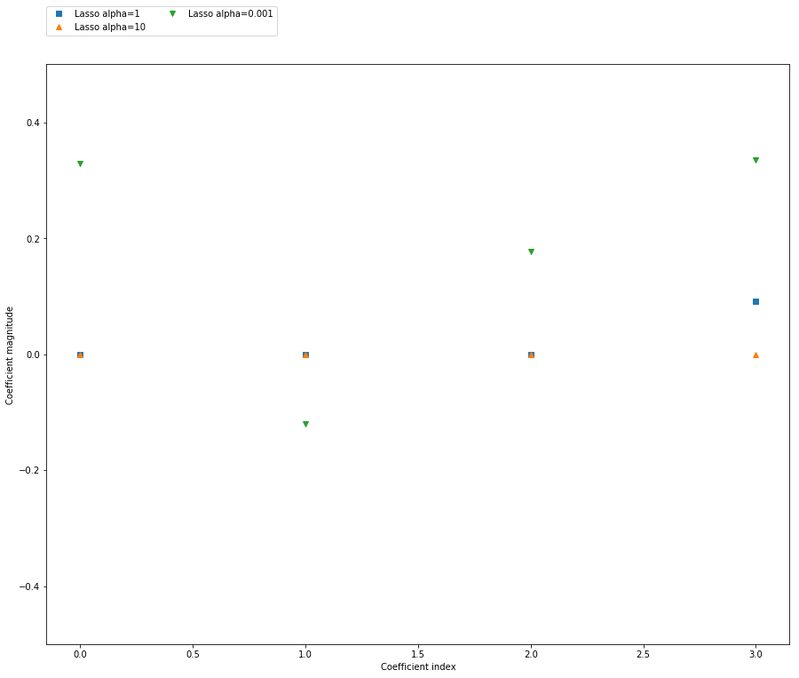

```python
plt.figure(figsize=(15,12))
plt.plot(lasso.coef_, 's', label="Lasso alpha=1")
plt.plot(lasso10.coef_, '^', label="Lasso alpha=10")
plt.plot(lasso0001.coef_, 'v', label="Lasso alpha=0.001")

plt.legend(ncol=2, loc=(0, 1.05))
plt.ylim(-0.5, 0.5)
plt.xlabel("Coefficient index")
plt.ylabel("Coefficient magnitude")
```

- based on graph when we increase alpha on lasso its extract some of features effects on model. So if we increase alpha so much, it cause high bias and low variance.

**References**

- https://www.quora.com/What-is-the-difference-between-L1-and-L2-regularization-How-does-it-solve-the-problem-of-overfitting-Which-regularizer-to-use-and-when

# 5.

Please run the code for iris dataset for three classification algorithms. Then determine the best one with explaining why you think this is the best one.

```python
iris_df = pd.DataFrame(data= np.c_[iris['data'], iris['target']],
                     columns= iris['feature_names'] + ['target'])

#iris_df = pd.DataFrame(data= np.c_[iris['data'], iris['target_names'][iris['target']]],
#                     columns= iris['feature_names'] + ['target'])

iris_df = shuffle(iris_df) # important to shuffle data
iris_X = iris_df[["sepal length (cm)","sepal width (cm)","petal length (cm)","petal width (cm)"]]
iris_y = iris_df["target"]
```

## KNeighborsClassifier

```python
from sklearn.neighbors import KNeighborsClassifier
KNeighborsClassifier()
```

```
KNeighborsClassifier(algorithm='auto', leaf_size=30, metric='minkowski',
           metric_params=None, n_jobs=1, n_neighbors=5, p=2,
           weights='uniform')
```

```python
neigh = KNeighborsClassifier()
scores_neight = cross_val_score(neigh, iris_X, iris_y, cv=5)
print(scores_neight)
print(np.mean(scores_neight))
```

```
[ 0.93333333  0.96666667  0.96666667  1.          0.96666667]
0.966666666667
```

```python
neigh = KNeighborsClassifier(leaf_size = 1000)
scores_neight = cross_val_score(neigh, iris_X, iris_y, cv=5)
print(scores_neight)
print(np.mean(scores_neight))
## leaf size does not change test score
```

```
[ 0.93333333  0.96666667  0.96666667  1.          0.96666667]
0.966666666667
```

```python
neigh = KNeighborsClassifier(n_jobs = 100)
scores_neight = cross_val_score(neigh, iris_X, iris_y, cv=5)
print(scores_neight)
print(np.mean(scores_neight))
## n_jobs does not change test score
```

```
[ 0.93333333  0.96666667  0.96666667  1.          0.96666667]
0.966666666667
```

```python
neigh = KNeighborsClassifier(n_neighbors = 7)
scores_neight = cross_val_score(neigh, iris_X, iris_y, cv=5)
print(scores_neight)
print(np.mean(scores_neight))
## n_neighbors change test score
```

```
[ 0.93333333  1.          0.96666667  1.          1.        ]
0.98
```

```python
neigh = KNeighborsClassifier(n_neighbors = 7,algorithm='brute')
# ball_tree = 0.973333333333
# kd_tree = 0.973333333333
# brute = 0.973333333333
scores_neight = cross_val_score(neigh, iris_X, iris_y, cv=5)
print(scores_neight)
print(np.mean(scores_neight))
## algorithm does not change test score
```

```
[ 0.93333333  1.          0.96666667  1.          1.        ]
0.98
```

```python
neigh = KNeighborsClassifier(n_neighbors = 7,algorithm='brute',weights = 'distance')
scores_neight = cross_val_score(neigh, iris_X, iris_y, cv=5)
print(scores_neight)
print(np.mean(scores_neight))
## weights change test score
```

```
[ 0.93333333  0.96666667  0.96666667  1.          1.        ]
0.973333333333
```

## RandomForestClassifier

```python
from sklearn.ensemble import RandomForestClassifier
from sklearn.datasets import make_classification
RandomForestClassifier()
```

```
RandomForestClassifier(bootstrap=True, class_weight=None, criterion='gini',
            max_depth=None, max_features='auto', max_leaf_nodes=None,
            min_impurity_decrease=0.0, min_impurity_split=None,
            min_samples_leaf=1, min_samples_split=2,
            min_weight_fraction_leaf=0.0, n_estimators=10, n_jobs=1,
            oob_score=False, random_state=None, verbose=0,
            warm_start=False)
```

```python
clf = RandomForestClassifier()
scores_ranforest = cross_val_score(clf, iris_X, iris_y, cv=5)
print(scores_ranforest)
print(np.mean(scores_ranforest))
```

```
[ 0.93333333  0.96666667  0.9         0.93333333  0.96666667]
0.94
```

```python
clf = RandomForestClassifier(max_depth=6)
scores_ranforest = cross_val_score(clf, iris_X, iris_y, cv=5)
print(scores_ranforest)
print(np.mean(scores_ranforest))
```

```
[ 0.9         0.96666667  0.9         0.93333333  1.        ]
0.94
```

## AdaBoostClassifier

```python
from sklearn.ensemble import AdaBoostClassifier
AdaBoostClassifier()
```

```
AdaBoostClassifier(algorithm='SAMME.R', base_estimator=None,
          learning_rate=1.0, n_estimators=50, random_state=None)
```

```python
clf = AdaBoostClassifier()
scores_ada = cross_val_score(clf, iris_X, iris_y, cv=5)
print(scores_ada)
print(np.mean(scores_ada))
```

```
[ 0.93333333  0.96666667  0.9         0.96666667  0.9       ]
0.933333333333
```

## GradientBoostingClassifier

```python
from sklearn.ensemble import GradientBoostingClassifier
GradientBoostingClassifier()
```

```
GradientBoostingClassifier(criterion='friedman_mse', init=None,
              learning_rate=0.1, loss='deviance', max_depth=3,
              max_features=None, max_leaf_nodes=None,
              min_impurity_decrease=0.0, min_impurity_split=None,
              min_samples_leaf=1, min_samples_split=2,
              min_weight_fraction_leaf=0.0, n_estimators=100,
              presort='auto', random_state=None, subsample=1.0, verbose=0,
              warm_start=False)
```

```python
clf = GradientBoostingClassifier(n_estimators=110, learning_rate=0.1,
    max_depth=1, random_state=1)
scores_boost = cross_val_score(clf, iris_X, iris_y, cv=5)
print(scores_boost)
print(np.mean(scores_boost))
```

```
[ 0.93333333  0.96666667  0.93333333  0.96666667  0.96666667]
0.953333333333
```

## LogisticRegression

```python
from sklearn.linear_model import LogisticRegression
LogisticRegression()
```

```
LogisticRegression(C=1.0, class_weight=None, dual=False, fit_intercept=True,
          intercept_scaling=1, max_iter=100, multi_class='ovr', n_jobs=1,
          penalty='l2', random_state=None, solver='liblinear', tol=0.0001,
          verbose=0, warm_start=False)
```

```python
clf = LogisticRegression()
scores_log = cross_val_score(clf, iris_X, iris_y, cv=5)
print(scores_log)
print(np.mean(scores_log))
```

```
[ 0.96666667  0.9         0.93333333  0.96666667  1.        ]
0.953333333333
```

## VotingClassifier and Deciding to which algorithm we choose

```python
from sklearn.ensemble import VotingClassifier
from sklearn.naive_bayes import GaussianNB
```

```python
clf1 = LogisticRegression(random_state=1)
clf2 = RandomForestClassifier(random_state=1)
clf3 = GaussianNB()
clf4 = KNeighborsClassifier(n_neighbors = 7)
clf5 = AdaBoostClassifier()
clf6 = GradientBoostingClassifier(n_estimators=110, learning_rate=0.1,
    max_depth=1, random_state=1)
eclf = VotingClassifier(estimators=[('lr', clf1), ('rf', clf2), ('gnb', clf3),
                                    ('neig',clf4),('ada',clf5),
                                    ('grad',clf6)], voting='hard')

for clf, label in zip([clf1, clf2, clf3, clf4, clf5, clf6, eclf],
                      ['Logistic Regression', 'Random Forest', 'naive Bayes', 'KNeighbors',
                       'Ada', 'Gradient', 'VotingClassifier']):
    scores = cross_val_score(clf, iris_X, iris_y, cv=5, scoring='accuracy')
    print("Accuracy: %0.2f (+/- %0.2f) [%s]" % (scores.mean(), scores.std(), label))
```

```
Accuracy: 0.95 (+/- 0.03) [Logistic Regression]
Accuracy: 0.95 (+/- 0.03) [Random Forest]
Accuracy: 0.95 (+/- 0.03) [naive Bayes]
Accuracy: 0.98 (+/- 0.03) [KNeighbors]
Accuracy: 0.93 (+/- 0.03) [Ada]
Accuracy: 0.95 (+/- 0.02) [Gradient]
Accuracy: 0.95 (+/- 0.03) [VotingClassifier]
```

## Result

Based on Accuracy mean and sd, I choose KNeighbors method.

### References

- http://scikit-learn.org/stable/modules/ensemble.html
- http://scikit-learn.org/stable/modules/generated/sklearn.neighbors.KNeighborsClassifier.html
- http://scikit-learn.org/stable/modules/generated/sklearn.ensemble.RandomForestClassifier.html
- http://scikit-learn.org/stable/modules/generated/sklearn.ensemble.AdaBoostClassifier.html
- http://scikit-learn.org/stable/modules/generated/sklearn.linear_model.LogisticRegression.html

# 6.

What’s the difference between Type I and Type II error? Explain your results with the outputs you obtained in the previous questions? (Hint: These errors are also known as false positive/negative).

### Answer

**Type 1 error:** reject true hypothesis so hypothesis actually true but we predict it false. **Type 2 error:** accept false hypothesis so hypothesis actually false but we predict it true.

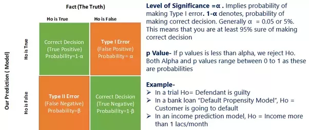

```python
from IPython.display import Image
from IPython.core.display import HTML
PATH = "/Users/yetkineser/Desktop/"
Image(filename = PATH + "errors.png", width=700, height=500)
```

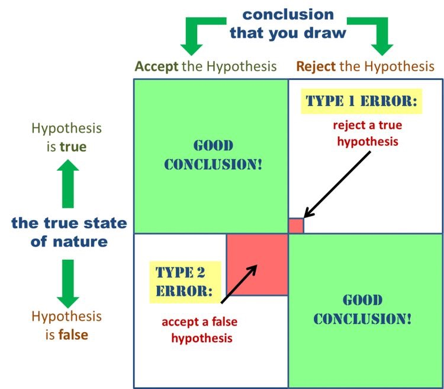

```python
Image(filename = PATH + "errors2.jpg", width=700, height=500)
```

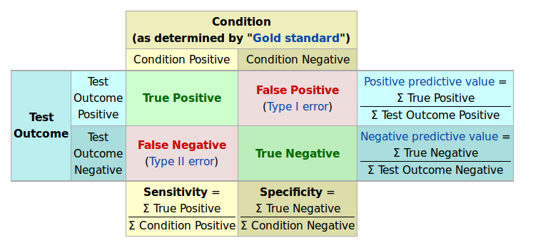

```python
Image(filename = PATH + "errors3.png", width=700, height=500)
```

# 7.

What are ensemble methods? What are they crucial and widely used? Provide a concrete example where ensemble techniques might be useful.

- Ramdom Forest
- AdaBoost
- Gradient Tree Boosting
- Voting Classifier are some of ensemble classifying methods.

Ensembling methohs are combine two or more algorithm like one. So predictions results based on more than one algorithms.

**its advantages**

- improving accuracy,
- more robust and stable performances

**disadvantages**

- reduce model interpretability
- time consuming

**Examples**

- I can give an example in question 5, i used some ensemble methods. Also ensemble methods are used in competition very often. But in real time applications using ensemble methods are not be the best idea because it is time consuming.
- Competition Example: https://www.kaggle.com/c/otto-group-product-classification-challenge/discussion/14335

### Useful Sources

- https://www.analyticsvidhya.com/blog/2015/08/introduction-ensemble-learning/
- https://www.analyticsvidhya.com/blog/2017/02/introduction-to-ensembling-along-with-implementation-in-r/
- https://blog.statsbot.co/ensemble-learning-d1dcd548e936
- https://mlwave.com/kaggle-ensembling-guide/

# 8.

We have already mentioned that it is important to have a balanced dataset for developing a good model. How would you handle an imbalanced dataset?

## Answer

- Collect more data
- Try to generate new data (Example: we can try to generate random new data from our minority class data set)
- We can use sensitivity, specifity or (sensitivity*specifity) rather than accuracy. (Try to be creative)

### References

- https://machinelearningmastery.com/tactics-to-combat-imbalanced-classes-in-your-machine-learning-dataset/
- https://www.analyticsvidhya.com/blog/2017/03/imbalanced-classification-problem/

# 9.

What is overfitting? How do you ensure you’re not overfitting with a model? (Hint: You can get help from this link: https://www.quora.com/How-can-I-avoid-overfitting)

## Answer

Methods for avoid overfittings are

- Cross Validation

which generate more than one training and test dataset to avoid overfitting. For model choosing it is so effective

- Early Stopping

- Pruning

Which remove some lowly effective nodes

- Regularization

Which decrease some features coefficient(distribute them for generelization)(Ridge) or delete some of features which cause some overfitting(Lasso).

### Useful Sources

- https://codeburst.io/what-is-regularization-in-machine-learning-aed5a1c36590
- https://www.quora.com/What-is-regularization-in-machine-learning
- https://www.analyticsvidhya.com/blog/2017/06/a-comprehensive-guide-for-linear-ridge-and-lasso-regression/
- https://www.analyticsvidhya.com/blog/2016/01/complete-tutorial-ridge-lasso-regression-python/
- https://www.analyticsvidhya.com/blog/2015/02/avoid-over-fitting-regularization/

# Useful Sources about ML

- https://www.analyticsvidhya.com/blog/2016/07/deeper-regression-analysis-assumptions-plots-solutions/
- https://www.analyticsvidhya.com/blog/2015/06/establish-causality-events/
- https://www.analyticsvidhya.com/blog/2016/09/40-interview-questions-asked-at-startups-in-machine-learning-data-science/
- https://www.analyticsvidhya.com/blog/2016/03/practical-guide-principal-component-analysis-python/
- https://www.kaggle.com/kashnitsky/vowpal-wabbit-tutorial-blazingly-fast-learning